# 1_mw_sleep

Jackie

05/31/21; 6/11/21; 7/4/21

This script wrangles MW subjctive sleep data and computes metrics (e.g., RMSSD) for further analysis

# 1 loading libraries

```r
library(tidyverse)
library(foreign)
library(haven)
library(readxl)
library(lubridate)
library(lmerTest)
```

Sach Note: “I have exported these documents as examples of the file formatting/data type from the new MetricWire platform so Jackie and I can create a new MW payment script. In total, each export will have 46 downloaded CSVs. The way our new study”ELS T3 Version 2" is set up, there are 43 morning assessments (Daily Sleep x 14, Daily Emotion x 14, Significant Events x 14, and an additional Sleep Diary Survey that counts as one assessment). There are 2 afternoon and evening assessments (Daily Sleep and Daily Emotion). There is one assessment on the last day of the study “ELS Sleep”.  
All of the morning surveys take the format of:  
1596828076222_Daily Sleep 8_00AM Survey - Day 1.csv  
1596828162532_Daily Emotion 8_00AM Survey - Day 1.csv  
1596828203346_Significant Events 8_00AM Survey - Day 1.csv  
[The above three surveys are identical for the 13 other day assessments, except the day number changes (e.g., 1596828076222_Daily Sleep 8_00AM Survey - Day 2.csv). The number at the front will also probably change w/ each export)  
1596828262046_Sleep Diary.csv [this captures sleep diary for all 14 days]"

# 2 Read in MW sleep data

```r
sleep_files <- Sys.glob(paste("~/Box/Mooddata_Coordinating/ELS_RDoC/At Home Components/3. MetricWire/Survey Monitoring/ELS_T3_Workspace_Version_2/Exported_data/","*","_Daily Sleep 8_00AM Survey - Day *.csv", sep = ""))
sleep_file_exp1 <- "~/Box/Mooddata_Coordinating/ELS_RDoC/At Home Components/3. MetricWire/Survey Monitoring/ELS_T3_Workspace_Version_1/Exported Data/1619543546838_Daily Sleep 6_45am Survey.csv"
```

# 3 cleaning MW_daily_sleep from the new MW version

Exports survey in as separate days - thus, building for loop to read in those files

```r
sleep_data_exp_v2_df <-
    data.frame(
        ELS_ID = NA,
        Session = NA,
        Survey_start_date = NA,
        triggerdate = NA,
        sleep_trigger_time = NA,
        DailySleep_hrs = NA,
        DailySleep_satisfaction = NA,
        DailySleep_hrs_rec = NA
    )

for (s in 1:length(sleep_files))
{

    sleepFile = Sys.glob(paste(sleep_files[s],sep=""))

    day = unlist(strsplit(sleep_files[s],'/'))[12]
    print(day)

    sleep_exp2 = read_csv(sleepFile) %>%
      rename(
        User_ID =
          `User Id`,
        Session =
          `Last Name`,
        ELS_ID =
          `First Name`,
        triggerdate =
          `Trigger Date`,
        sleep_trigger_time =
          `Trigger Time`,
        DeviceOS =
          `Device OS`,
        Survey_start_date =
          `Survey Started Date`,
        DailySleep_hrs =
          `How many hours did you sleep last night?`,
        DailySleep_satisfaction =
          `How restful or satisfying was your sleep last night?`
        ) %>%
      mutate(
        User_ID = as.factor(User_ID)
        ) %>%
      dplyr::select(-c(`Response Id`,
                       `Submission Location`,
                       `Trigger Id`,
                       `Device Id`)
                    ) %>%
      mutate(
        DailySleep_hrs = as.factor(DailySleep_hrs)
        ) %>%
      mutate(
        DailySleep_hrs_rec =
          recode_factor(DailySleep_hrs,
                        "5hr or less" = 5,
                        "6 hr." = 6,
                        "7hr." = 7,
                        "8hr." = 8,
                        "9hr. or more" = 9)
        ) %>%
      mutate(
        DailySleep_hrs_rec =
          as.character(DailySleep_hrs_rec)
        ) %>%
      mutate(DailySleep_hrs_rec =
               as.numeric(DailySleep_hrs_rec)
             )

    sleep_exp2_select <-
      sleep_exp2 %>%
      dplyr::select(ELS_ID,
                    Session,
                    Survey_start_date,
                    triggerdate,
                    sleep_trigger_time,
                    DailySleep_hrs,
                    DailySleep_satisfaction,
                    DailySleep_hrs_rec)

    sleep_data_exp_v2_df <- bind_rows(sleep_data_exp_v2_df, sleep_exp2_select)

}
```

```
## [1] "1623125974368_Daily Sleep 8_00AM Survey - Day 1.csv"
## [1] "1623126061092_Daily Sleep 8_00AM Survey - Day 2.csv"
## [1] "1623126500560_Daily Sleep 8_00AM Survey - Day 3.csv"
## [1] "1623130617930_Daily Sleep 8_00AM Survey - Day 4.csv"
## [1] "1623130806881_Daily Sleep 8_00AM Survey - Day 5.csv"
## [1] "1623131058678_Daily Sleep 8_00AM Survey - Day 6.csv"
## [1] "1623131154598_Daily Sleep 8_00AM Survey - Day 7.csv"
## [1] "1623131251761_Daily Sleep 8_00AM Survey - Day 8.csv"
## [1] "1623131342091_Daily Sleep 8_00AM Survey - Day 9.csv"
## [1] "1623131562553_Daily Sleep 8_00AM Survey - Day 10.csv"
## [1] "1623131700778_Daily Sleep 8_00AM Survey - Day 11.csv"
## [1] "1623131812781_Daily Sleep 8_00AM Survey - Day 12.csv"
## [1] "1623131904078_Daily Sleep 8_00AM Survey - Day 13.csv"
## [1] "1623131986236_Daily Sleep 8_00AM Survey - Day 14.csv"
```

```r
sleep_data_exp_v2_df <-
  sleep_data_exp_v2_df %>%
  drop_na(ELS_ID)
```

# 4 cleaning MW_daily_sleep from the older MW version

Exports survey as one csv for all days

```r
sleep_exp1 <- read_csv(sleep_file_exp1)

sleep_exp1_clean <-
  sleep_exp1 %>%
  rename(
    User_ID =
      `User Id`,
    Session =
      `Last Name`,
    ELS_ID =
      `First Name`,
    Survey_start_date =
      `Survey Started Date`,
    triggerdate =
      `Trigger Date`,
    sleep_trigger_time =
      `Trigger Time`,
    DeviceOS =
      `Device OS`,
    DailySleep_hrs =
      `How many hours did you sleep last night?`,
    DailySleep_satisfaction =
      `How restful or satisfying was your sleep last night?`
    ) %>%
  mutate(
    User_ID = as.factor(User_ID)
    ) %>%
  dplyr::select(-c(`Response Id`,
                   `Submission Location`,
                   `Trigger Id`,
                   `Device Id`)
                ) %>%
  mutate(
    DailySleep_hrs = as.factor(DailySleep_hrs)
    ) %>%
  mutate(
    DailySleep_hrs_rec =
      recode_factor(
        DailySleep_hrs,
        "5hr or less" = 5,
        "6 hr." = 6,
        "7hr." = 7,
        "8hr." = 8,
        "9hr. or more" = 9)
    ) %>%
  mutate(
    DailySleep_hrs_rec =
      as.character(DailySleep_hrs_rec)
    ) %>%
  mutate(DailySleep_hrs_rec =
           as.numeric(DailySleep_hrs_rec)
         )

sleep_exp1_select <-
  sleep_exp1_clean %>%
  dplyr::select(ELS_ID,
                Session,
                Survey_start_date,
                triggerdate,
                sleep_trigger_time,
                DailySleep_hrs,
                DailySleep_satisfaction,
                DailySleep_hrs_rec) %>%
  drop_na(ELS_ID)
```

## 4.1 binding dataframes

```r
sleep_data_exp_v1and2_df <- bind_rows(sleep_exp1_select, sleep_data_exp_v2_df)
```

### 4.1.1 pulling out only “c”

```r
sleep_data_exp_v1and2_df_c <-
  sleep_data_exp_v1and2_df %>%
  mutate(
    porc =
      ifelse(str_detect(ELS_ID, "c"),
             "C",
             "P"
             )
    )

sleep_data_exp_v1and2_df_c <-
  sleep_data_exp_v1and2_df_c %>%
  filter(
    porc == "C"
  )

sleep_data_exp_v1and2_df_c_clean <-
  sleep_data_exp_v1and2_df_c %>%
  mutate(
    ELS_ID =
      str_remove_all(ELS_ID,
                     "[c]")
    ) %>%
  filter(
    ELS_ID != "Jalyn",
    ELS_ID != "jalyn",
    ELS_ID != "sah",
    ELS_ID != "vanessa"
  ) %>%
  mutate(ELS_ID =
           as.numeric(ELS_ID)
         ) %>%
  dplyr::select(
    ELS_ID,
    Session,
    Survey_start_date,
    triggerdate,
    sleep_trigger_time,
    DailySleep_hrs,
    DailySleep_satisfaction,
    DailySleep_hrs_rec
    ) %>%
  mutate(
    ELS_ID =
      as.factor(ELS_ID)
  )
```

### 4.1.2 parsing dates

```r
sleep_data_exp_v1and2_df_c_clean_date <-
  sleep_data_exp_v1and2_df_c_clean %>%
  mutate(
    triggerdate = dmy(triggerdate),
    surveystartdate = dmy(Survey_start_date)
  )
```

### 4.1.3 creating day and week variables

```r
# creating day and week variables
sleep_data_exp_v1and2_df_c_clean_day <-
  sleep_data_exp_v1and2_df_c_clean_date %>%
  mutate(
    day = day(triggerdate),
    wday = wday(triggerdate, label = TRUE),
    ELS_ID = factor(ELS_ID)
  )

# day num
sleep_data_exp_v1and2_df_c_clean_dayorder  <-
  sleep_data_exp_v1and2_df_c_clean_day %>%
  group_by(ELS_ID) %>%
  mutate(
    dayorder = order(triggerdate)
    )
```

### 4.1.4 wkday or wkend

```r
sleep_data_exp_v1and2_df_c_clean_dayorder <-
  sleep_data_exp_v1and2_df_c_clean_dayorder %>%
  mutate(
    week =
      ifelse(
        wday == "Sun" |
          wday == "Sat",
        "wkend",
        "wkday"
      )
  )
```

## 4.2 dealing with not enough or missing data

if there are fewer than 3 days of data, I’m removing the subject

```r
# how many days per individual?
sleep_data_exp_v1and2_df_c_clean_dayorder <-
  sleep_data_exp_v1and2_df_c_clean_dayorder %>%
  group_by(ELS_ID) %>%
  mutate(
    data_num_obs =
      max(dayorder)
  ) %>%
  drop_na(DailySleep_satisfaction) %>%
  drop_na(week)

## how many subjects are we starting out with?
sum_N <-
  sleep_data_exp_v1and2_df_c_clean_dayorder %>%
  group_by(ELS_ID) %>%
  summarize(
    n = n()
  ) # starting off with 141

# filter those who have more than 3 days
sleep_data_exp_v1and2_df_c_clean_filter  <-
  sleep_data_exp_v1and2_df_c_clean_dayorder %>%
  group_by(ELS_ID) %>%
  filter(
    data_num_obs >= 3
  ) %>%
  filter(
    dayorder < 15
  ) %>%
  mutate(
    Session = str_remove(Session, "ELS-")
  )

## how many subjects can we analyze?
sum_N <-
  sleep_data_exp_v1and2_df_c_clean_filter %>%
  group_by(ELS_ID) %>%
  summarize(
    n = n()
  ) # 127
```

# 5 data viz

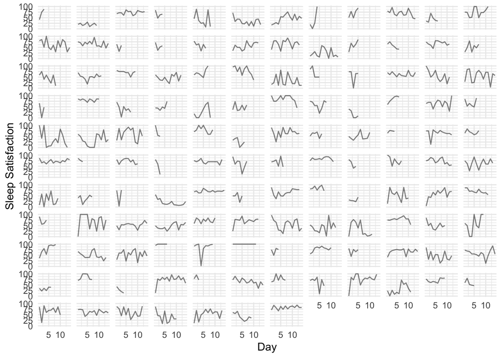

```r
sleep_data_exp_v1and2_df_c_clean_filter %>%
  ggplot(aes(dayorder, DailySleep_satisfaction,
        group = ELS_ID)) +
      geom_line(alpha = 1/2) +
  facet_wrap(~ELS_ID) +
  theme_minimal() +
  theme(
  strip.text.x = element_blank()
  ) +
  labs(
    x = "Day",
    y = "Sleep Satisfaction"
    )
```

```r
ggsave("daily_mw_sleep_traj.png", width = 7, height = 7, dpi = 400)
```

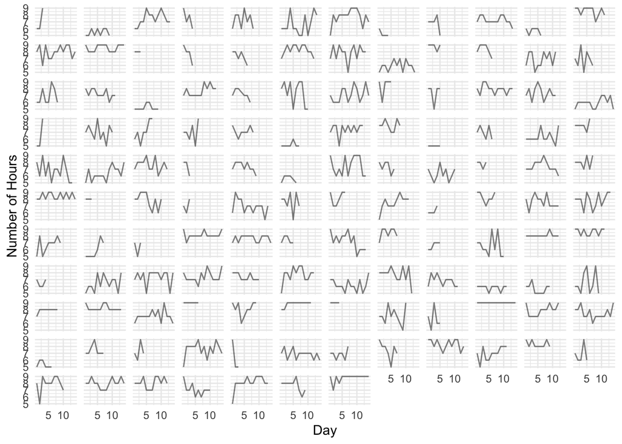

```r
sleep_data_exp_v1and2_df_c_clean_filter %>%
  ggplot(aes(dayorder, DailySleep_hrs_rec,
        group = ELS_ID)) +
      geom_line(alpha = 1/2) +
  facet_wrap(~ELS_ID) +
  theme_minimal() +
  theme(
  strip.text.x = element_blank()
  ) +
  labs(
    x = "Day",
    y = "Number of Hours"
    )
```

```r
ggsave("daily_mw_sleep_hrs_traj.png", width = 7, height = 7, dpi = 400)
```

### 5.0.1 distribution of weekday vs. weekend and association with sleep sat and hrs

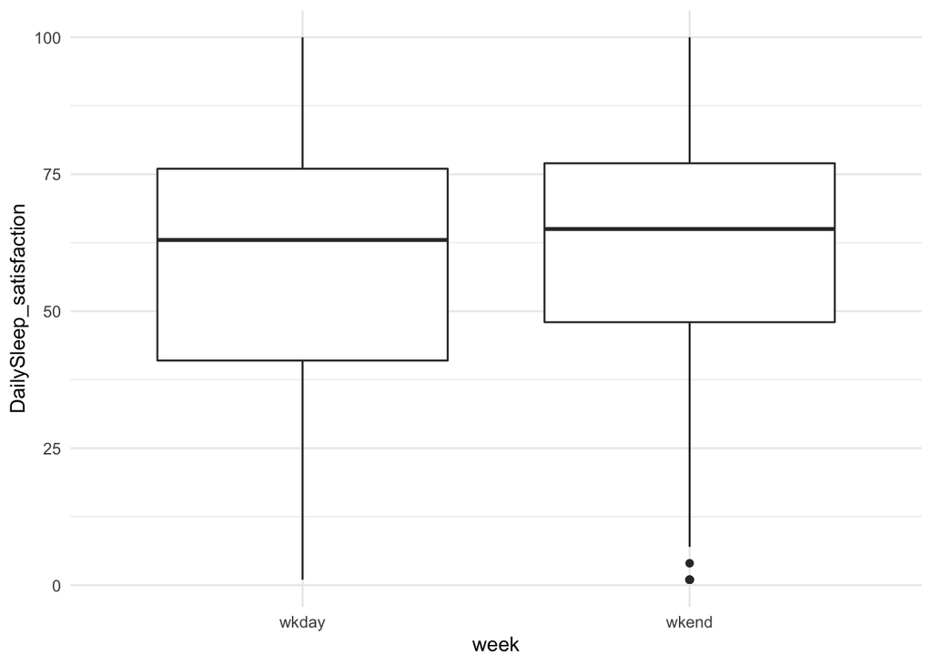

```r
sleep_data_exp_v1and2_df_c_clean_filter %>%
  ggplot(
    aes(x = week, y = DailySleep_satisfaction )
  ) +
  geom_boxplot() +
  theme_minimal()
```

```r
summary(lmer(scale(DailySleep_satisfaction) ~ dayorder +factor(week) + (1|ELS_ID), data = sleep_data_exp_v1and2_df_c_clean_filter))
```

```
## Linear mixed model fit by REML. t-tests use Satterthwaite's method [
## lmerModLmerTest]
## Formula: scale(DailySleep_satisfaction) ~ dayorder + factor(week) + (1 |
##     ELS_ID)
##    Data: sleep_data_exp_v1and2_df_c_clean_filter
##
## REML criterion at convergence: 2976.9
##
## Scaled residuals:
##     Min      1Q  Median      3Q     Max
## -4.0913 -0.5684  0.0684  0.5818  3.1584
##
## Random effects:
##  Groups   Name        Variance Std.Dev.
##  ELS_ID   (Intercept) 0.4138   0.6432
##  Residual             0.5913   0.7690
## Number of obs: 1175, groups:  ELS_ID, 127
##
## Fixed effects:
##                     Estimate Std. Error         df t value Pr(>|t|)
## (Intercept)       -1.658e-02  7.354e-02  2.439e+02  -0.225   0.8218
## dayorder          -3.983e-03  6.894e-03  1.116e+03  -0.578   0.5635
## factor(week)wkend  1.367e-01  5.318e-02  1.069e+03   2.570   0.0103 *
## ---
## Signif. codes:  0 '***' 0.001 '**' 0.01 '*' 0.05 '.' 0.1 ' ' 1
##
## Correlation of Fixed Effects:
##             (Intr) dayrdr
## dayorder    -0.507
## fctr(wk)wkn -0.212  0.075
```

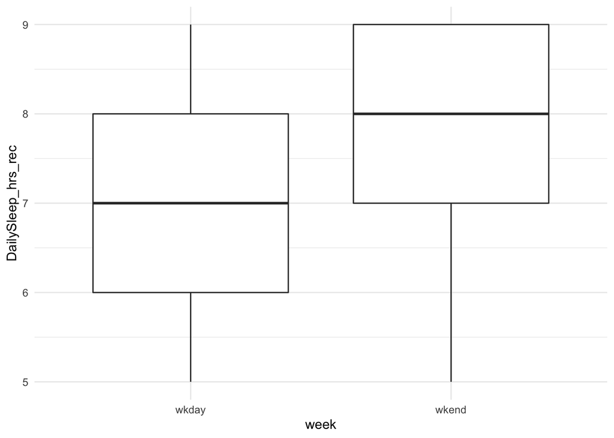

```r
sleep_data_exp_v1and2_df_c_clean_filter %>%
  ggplot(
    aes(x = week, y = DailySleep_hrs_rec )
  ) +
  geom_boxplot() +
  theme_minimal()
```

```r
summary(lmer(scale(DailySleep_hrs_rec) ~ dayorder + factor(week) + (1|ELS_ID), data = sleep_data_exp_v1and2_df_c_clean_filter))
```

```
## Linear mixed model fit by REML. t-tests use Satterthwaite's method [
## lmerModLmerTest]
## Formula: scale(DailySleep_hrs_rec) ~ dayorder + factor(week) + (1 | ELS_ID)
##    Data: sleep_data_exp_v1and2_df_c_clean_filter
##
## REML criterion at convergence: 2971.8
##
## Scaled residuals:
##      Min       1Q   Median       3Q      Max
## -3.04411 -0.57566  0.03793  0.62984  2.60074
##
## Random effects:
##  Groups   Name        Variance Std.Dev.
##  ELS_ID   (Intercept) 0.4252   0.6520
##  Residual             0.5869   0.7661
## Number of obs: 1175, groups:  ELS_ID, 127
##
## Fixed effects:
##                     Estimate Std. Error         df t value Pr(>|t|)
## (Intercept)       -1.435e-01  7.404e-02  2.354e+02  -1.938  0.05379 .
## dayorder           1.234e-02  6.872e-03  1.113e+03   1.796  0.07275 .
## factor(week)wkend  1.393e-01  5.299e-02  1.066e+03   2.628  0.00871 **
## ---
## Signif. codes:  0 '***' 0.001 '**' 0.01 '*' 0.05 '.' 0.1 ' ' 1
##
## Correlation of Fixed Effects:
##             (Intr) dayrdr
## dayorder    -0.501
## fctr(wk)wkn -0.210  0.075
```

```r
sleep_week <-
  sleep_data_exp_v1and2_df_c_clean_filter %>%
  group_by(ELS_ID, week) %>%
  summarize(
    n = n()
  )
```

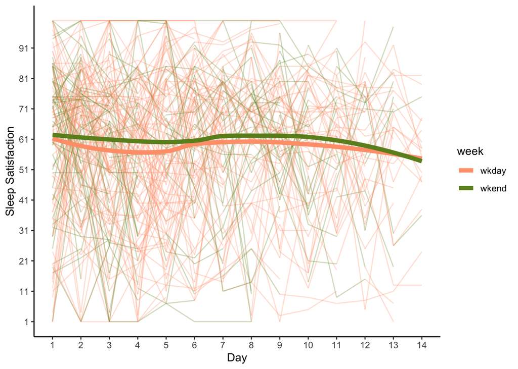

```r
sleep_data_exp_v1and2_df_c_clean_filter_spread <-
  sleep_data_exp_v1and2_df_c_clean_filter %>%
  spread(week, DailySleep_satisfaction)

ts_plot <- sleep_data_exp_v1and2_df_c_clean_filter %>%
  ggplot(
    aes(
      x = dayorder,
      y = DailySleep_satisfaction,
      color = week
    )
  ) +
  geom_line(aes(group = ELS_ID, color = week), alpha = .3) +
  geom_smooth(method = "loess", se=FALSE, size = 2) +
  theme_classic() +
  scale_x_continuous(
    name = "Day",
    limits = c(1, 14),
    breaks = seq(1, 14, 1)
    ) +
   scale_y_continuous(
    name = "Sleep Satisfaction",
    limits = c(1, 100),
    breaks = seq(1, 100, 10)
    ) +
  scale_color_manual(values = c("#FFA07A","#6B8E23"))
ts_plot
```

```r
ggsave("sleepsat_byDay_byWkdayWkend.png", ts_plot, width = 7, height = 6)
```

### 5.0.2 write

```r
sleep_data_exp_v1and2_df_c_clean_filter <-
  sleep_data_exp_v1and2_df_c_clean_filter %>%
  dplyr::select(-Survey_start_date)
write_csv(sleep_data_exp_v1and2_df_c_clean_filter, "~/Box/Mooddata_Coordinating/1_Lab_Coordinating/Users/JackieSchwartz/Dissertation/0_MW_Act_Demo_Descriptives/MW_daily_sleep_data_longform.csv")
```

# 6 sleep instability?

given the huge amounts of variability in sleep satisfaction, the mean may not be an accurate representation computing the rmssd as per Koval et al., 2013; Jahng et al., 2008 The RMSSD is measured as the square root of the average of the squared differences between affect at measurement i and i + 1 (Schoevers et al., 2020)

```r
ssd_df <-
  sleep_data_exp_v1and2_df_c_clean_filter %>%
  dplyr::select(
    ELS_ID, surveystartdate, dayorder, DailySleep_satisfaction, DailySleep_hrs_rec
  ) %>%
  group_by(ELS_ID) %>%
  summarize(
    # step 1: computing successive difference
    sleep_succ_diff = DailySleep_satisfaction - lag(DailySleep_satisfaction),
    sleep_hrs_succ_diff = DailySleep_hrs_rec - lag(DailySleep_hrs_rec),
    # step 2: computing square of each diff
    sleep_sq_succ_diff = sleep_succ_diff^2,
    sleep_hrs_sq_succ_diff = sleep_hrs_succ_diff^2
  ) %>%
  ungroup()
mssd_df <-
  ssd_df %>%
  group_by(ELS_ID) %>%
  summarize(
    # step 3: averaging the squared differences
    mean_sq_succ_diff = mean(sleep_sq_succ_diff, na.rm = TRUE),
    mean_sq_succ_diff_hrs = mean(sleep_hrs_sq_succ_diff, na.rm = TRUE),
    # step 4: computing square root of the average
    rmssd_sleep = sqrt(mean_sq_succ_diff),
    rmssd_sleep_hrs = sqrt(mean_sq_succ_diff_hrs)
  ) %>%
  mutate(ELS_ID = factor(ELS_ID)) %>%
  ungroup()
```

### 6.0.1 computign the mean and dispersion (sd)

```r
mw_sleep_red <-
  sleep_data_exp_v1and2_df_c_clean_filter %>%
  group_by(ELS_ID) %>%
  summarize(
    dailysleep_sat_mean = mean(DailySleep_satisfaction, na.rm = TRUE),
    dailysleep_sat_sd = sd(DailySleep_satisfaction, na.rm = TRUE),
    dailysleep_hrs_mean = mean(DailySleep_hrs_rec, na.rm = TRUE),
    dailysleep_hrs_sd = sd(DailySleep_hrs_rec, na.rm = TRUE)
  ) %>%
  mutate(ELS_ID = factor(ELS_ID)) %>%
  ungroup()
```

#### 6.0.1.1 joining dataframes

```r
mw_sleep_red <-
  left_join(
    mw_sleep_red,
    mssd_df,
    by = "ELS_ID"
  )


# joining the df with survey start date
sleep_data_exp_v1and2_df_c_clean_filter_select <-
  sleep_data_exp_v1and2_df_c_clean_filter %>%
  dplyr::select(
    ELS_ID, surveystartdate
  ) %>%
  group_by(ELS_ID) %>%
  mutate(
    startdate =
      min(surveystartdate)
    ) %>%
  dplyr::select(ELS_ID, startdate) %>%
  unique() %>%
  mutate(ELS_ID = factor(ELS_ID)) %>%
  ungroup()

mw_sleep_red <-
  left_join(
    sleep_data_exp_v1and2_df_c_clean_filter_select,
    mw_sleep_red,
    by = "ELS_ID"
  )
```

## 6.1 summary stats

```r
mw_sleep_red_summary <-
  mw_sleep_red %>%
  summarize(
    n = n(),
   dailysleep_sat_mean_sum = mean(dailysleep_sat_mean),
   dailysleep_sat_sd_sum = sd(dailysleep_sat_mean),
   dailysleep_hrs_mean_sum = mean(dailysleep_hrs_mean),
   dailysleep_hrs_sd_sum = sd(dailysleep_hrs_mean)
  )
write_csv(mw_sleep_red_summary, "mw_sleep_red_summary.csv")
```

## 6.2 distribution of mean sleep satisfaction and mean hours

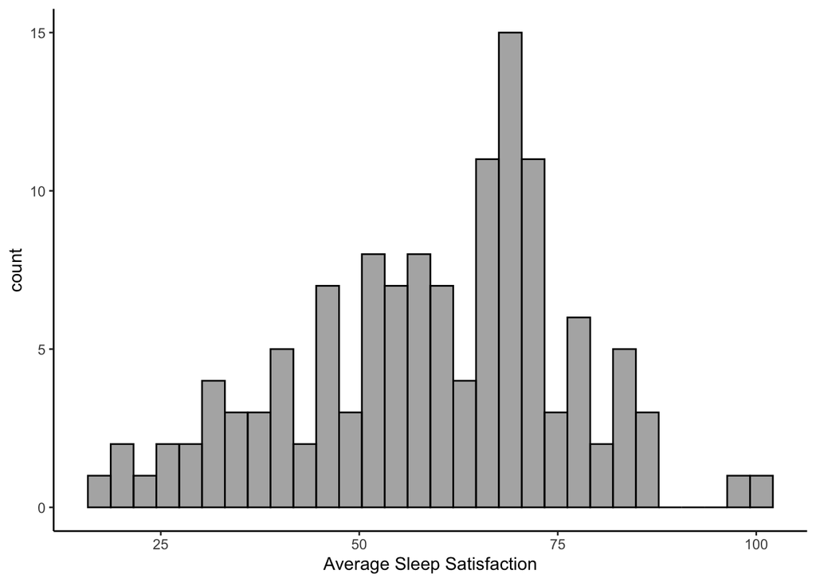

```r
dailysat_mean <-
  mw_sleep_red %>%
  ggplot(
    aes(x=dailysleep_sat_mean)
  ) +
  geom_histogram(alpha=.5, color="black") +
  theme_classic() +
  labs(
    x = "Average Sleep Satisfaction"
  )
dailysat_mean
```

```r
ggsave("dailysat_mean.png", dailysat_mean, width = 7, height = 6.5)
```

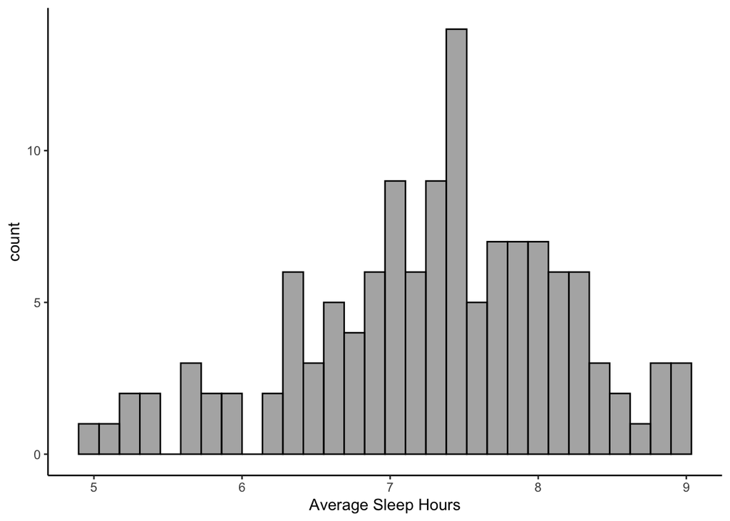

```r
dailyhrs_mean <-
  mw_sleep_red %>%
  ggplot(
    aes(x=dailysleep_hrs_mean)
  ) +
  geom_histogram(alpha=.5, color="black") +
  theme_classic() +
  labs(
    x = "Average Sleep Hours"
  )
dailyhrs_mean
```

```r
ggsave("dailyhrs_mean.png", dailyhrs_mean, width = 7, height = 6.5)
```

## 6.3 distribution of sleep satisfaction and sleep hrs dispersion

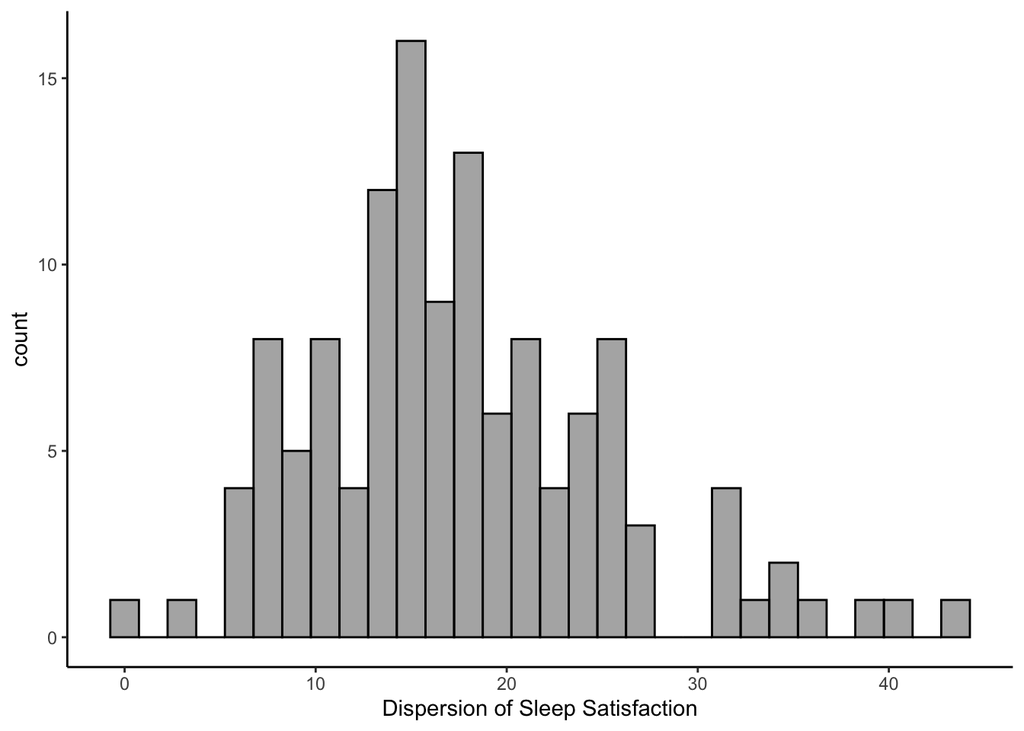

```r
dailysat_sd <- mw_sleep_red %>%
  ggplot(
    aes(x=dailysleep_sat_sd)
  ) +
  geom_histogram(alpha=.5, color="black") +
  theme_classic() +
  labs(
    x = "Dispersion of Sleep Satisfaction"
  )
dailysat_sd
```

```r
ggsave("dailysat_sd.png", dailysat_sd, width = 7, height = 6.5)
```

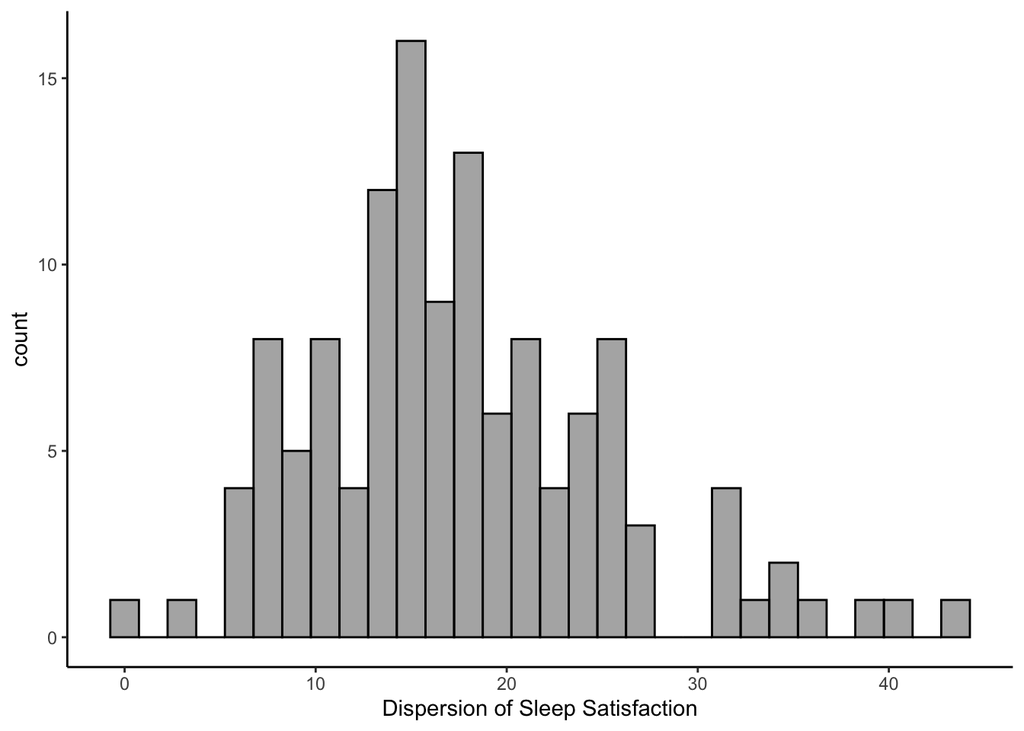

```r
dailyhrs_sd <- mw_sleep_red %>%
  ggplot(
    aes(x=dailysleep_hrs_sd)
  ) +
  geom_histogram(alpha=.5, color="black") +
  theme_classic() +
  labs(
    x = "Dispersion of Sleep Hours"
  )
dailysat_sd
```

```r
ggsave("dailyhrs_sd.png", dailyhrs_sd, width = 7, height = 6.5)
```

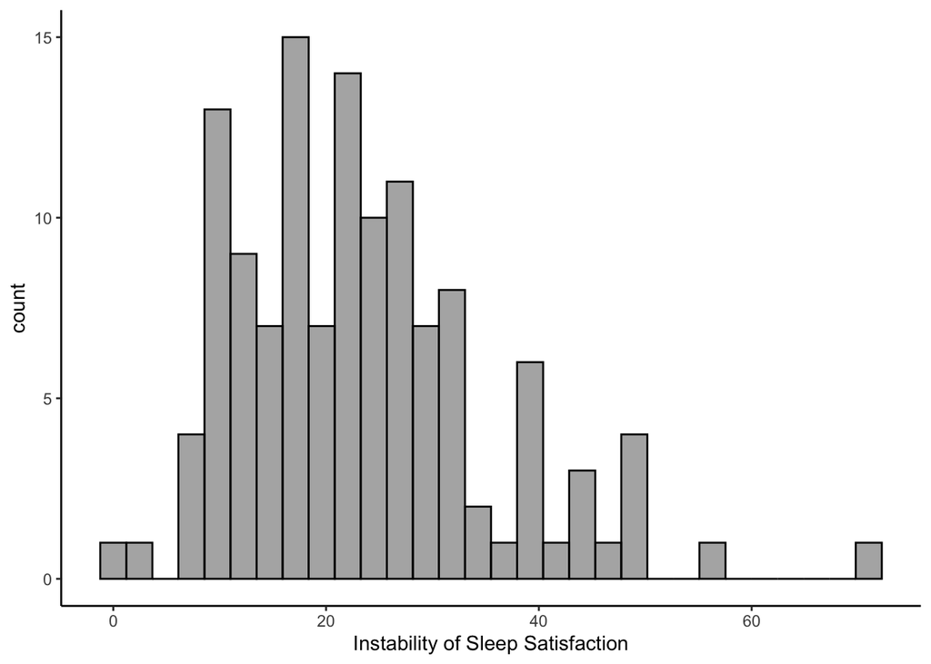

```r
dailysat_rmssd <- mw_sleep_red %>%
  ggplot(
    aes(x=rmssd_sleep)
  ) +
  geom_histogram(alpha=.5, color="black") +
  theme_classic() +
  labs(
    x = "Instability of Sleep Satisfaction"
  )
dailysat_rmssd
```

```r
ggsave("dailysat_rmssd.png", dailysat_rmssd, width = 7, height = 6.5)
```

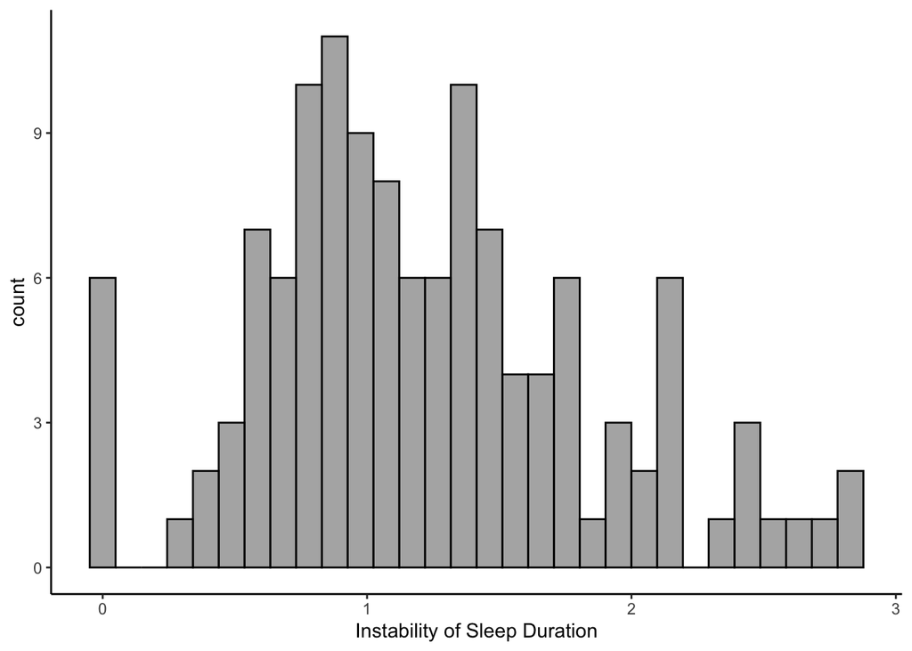

```r
dailyhrs_rmssd <- mw_sleep_red %>%
  ggplot(
    aes(x=rmssd_sleep_hrs)
  ) +
  geom_histogram(alpha=.5, color="black") +
  theme_classic() +
  labs(
    x = "Instability of Sleep Duration"
  )
dailyhrs_rmssd
```

```r
ggsave("dailyhrs_rmssd.png", dailyhrs_rmssd, width = 7, height = 6.5)
```

### 6.4.1 write

```r
write_csv(mw_sleep_red, "~/Box/Mooddata_Coordinating/1_Lab_Coordinating/Users/JackieSchwartz/Dissertation/0_MW_Act_Demo_Descriptives/MW_daily_sleep_data_reduced.csv")
```